# Machine Learning Lab - 5

### Import the datasets and modules

```python
from sklearn.datasets import make_circles
from sklearn.datasets import make_moons

import matplotlib.pyplot as plt
from sklearn.cluster import KMeans
from sklearn.cluster import AgglomerativeClustering
from sklearn.cluster import SpectralClustering
```

## Circles dataset (45 points)

**Visually represent Circles dataset (2 points)**

Do not give centers and n_features parameters here. Instead give factor = 0.5 and noise = 0.05

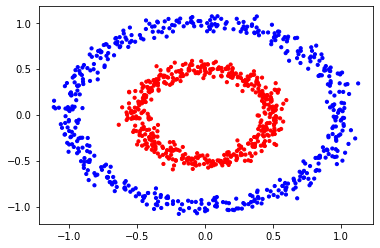

```python
# Write the code for plotting the circles dataset here

X, y = make_circles(n_samples=1000, factor = 0.5, noise = 0.05, random_state=0)
plt.scatter(X[:, 0], X[:, 1], s=10, c=y, cmap='bwr')
plt.show()
```

### KMeans Clustering (15 points)

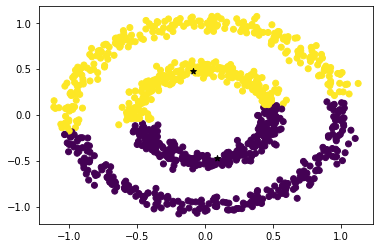

```python
## Write the code for KMeans with 2 clusters, print the cluster centers and plot the data
clf = KMeans(n_clusters = 2)
clf.fit(X)
centers = clf.cluster_centers_
centers
plt.scatter(X[:,0],X[:,1],c=clf.labels_)
plt.scatter(centers[:,0],centers[:,1],c='black',marker='*')
plt.show()
```

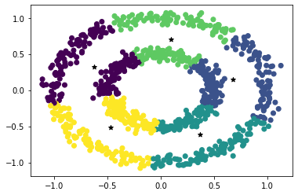

```python
## Write the code for KMeans with 5 clusters, print the cluster centers and plot the data

clf = KMeans(n_clusters = 5)
clf.fit(X)
centers = clf.cluster_centers_
centers
plt.scatter(X[:,0],X[:,1],c=clf.labels_)
plt.scatter(centers[:,0],centers[:,1],c='black',marker='*')
plt.show()
```

### Agglomerative Clustering (15 points)

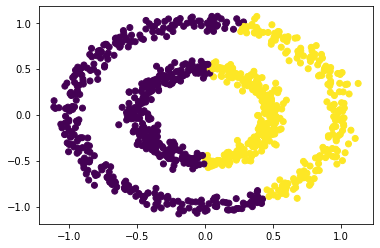

```python
## Write the code for Agglomerative Clustering with 2 clusters, print the labels and plot the data
clf = AgglomerativeClustering(n_clusters=2)
clf.fit(X)
labels = clf.labels_
#labels
plt.scatter(X[:,0],X[:,1],c=clf.labels_)
plt.show()
```

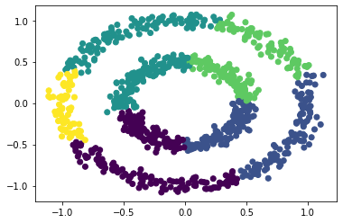

```python
## Write the code for Agglomerative Clustering with 5 clusters, print the labels and plot the data
clf = AgglomerativeClustering(n_clusters=5)
clf.fit(X)
labels = clf.labels_
#labels
plt.scatter(X[:,0],X[:,1],c=clf.labels_)
plt.show()
```

### Spectral Clustering (15 points)

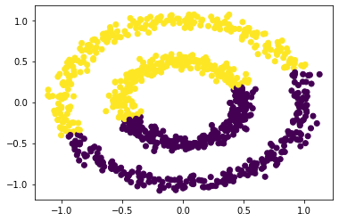

```python
## Write the code for Spectral Clustering with 2 clusters, print the labels and plot the data
clf = SpectralClustering(n_clusters=2, assign_labels='discretize', random_state=0)
clf.fit(X)
plt.scatter(X[:,0],X[:,1],c=clf.labels_)
plt.show()
```

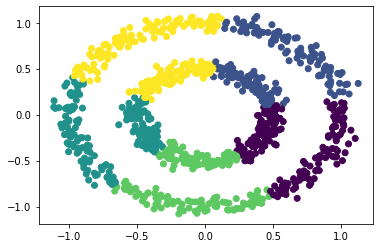

```python
## Write the code for Spectral Clustering with 5 clusters, print the labels and plot the data
clf = SpectralClustering(n_clusters=5, assign_labels='discretize', random_state=0)
clf.fit(X)
plt.scatter(X[:,0],X[:,1],c=clf.labels_)
plt.show()
```

**Write a small summary after observing the 6 figures of the Circles dataset on the top (3 marks)**

# Write the summary here

**This type of clustering is used for unsupervised data. The make_circles is imported from sklearn dataset. With the help of the make_circle a 2D visual view can be classified. Here we imported the clustering algorithms from the sklearn. The algorithms are KMeans,AgglomerativeClustering and SpectralClustering.

**Brief about the above input cell steps.

In [1]: we import the required functions and algorithms from the dataset and clusters.

In [2]: we have writtern the code for plotting the circular format of the dataset and represented them.

In [4]: we invoke the KMeans by considering the 2 clusters and assign the scattered cordinates to them.With the help of this we represent the circular visual 2-d view.

In [8]: Similarly,we invoke the KMeans by considering the 5 clusters and assign the scattered cordinates to them.With the help of this we represent the circular visual 2-d view.

In [9]: Now consider the Agglomerative Clustering, and define the 2 clusters. After that assign to the label variable and then scatter the coordinates and print them in the form of circles with 2-D view.

In [11]: Now consider the Agglomerative Clustering, and define the 5 clusters. After that assign to the label variable and then scatter the coordinates and print them in the form of circles with 2-D view.

In [12]: Now similarly, consider the Spectral Clustering with 2 clusters and define them. Then declare the label and then scatter the coordinates and plot the circle with 2-d view.

In [13]: consider the Spectral Clustering with 5 clusters and define them. Then declare the label and then scatter the coordinates and plot the circle with 2-d view.

**In this way we can visualize the 2-D view for the dataset.**

## Moons dataset (45 points)

**Visually represent Moons dataset (2 points)**

Here, do not give centers, n_features or factor parameters here. Instead give noise = 0.05

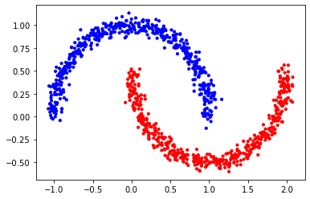

```python
# Write the code for plotting the moons dataset here

X, y = make_moons(n_samples=1000, noise = 0.05, random_state=0)
plt.scatter(X[:, 0], X[:, 1], s=10, c=y, cmap='bwr')
plt.show()
```

### KMeans Clustering (15 points)

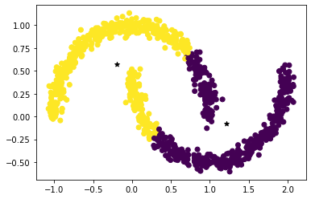

```python
# Write the code for KMeans Clustering with 2 clusters, print the cluster centers and plot the data

clf = KMeans(n_clusters = 2)
clf.fit(X)
centers = clf.cluster_centers_

plt.scatter(X[:,0],X[:,1],c=clf.labels_)
plt.scatter(centers[:,0],centers[:,1],c='black',marker='*')
plt.show()
```

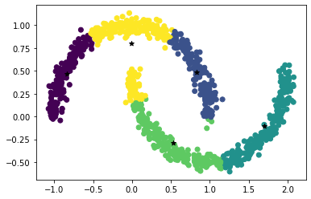

```python
# Write the code for KMeans Clustering with 5 clusters, print the cluster centers and plot the data

clf = KMeans(n_clusters = 5)
clf.fit(X)
centers = clf.cluster_centers_
plt.scatter(X[:,0],X[:,1],c=clf.labels_)
plt.scatter(centers[:,0],centers[:,1],c='black',marker='*')
plt.show()
```

### Agglomerative Clustering (15 points)

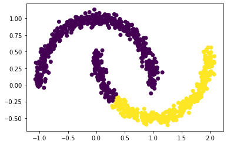

```python
# Write the code for Agglomerative Clustering with 2 clusters, print the labels and plot the data

clf = AgglomerativeClustering(n_clusters=2)
clf.fit(X)
labels = clf.labels_
plt.scatter(X[:,0],X[:,1],c=clf.labels_)
plt.show()
```

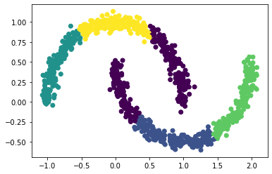

```python
# Write the code for Agglomerative Clustering with 5 clusters, print the labels and plot the data

clf = AgglomerativeClustering(n_clusters=5)
clf.fit(X)
labels = clf.labels_

plt.scatter(X[:,0],X[:,1],c=clf.labels_)
plt.show()
```

### Spectral Clustering (15 points)

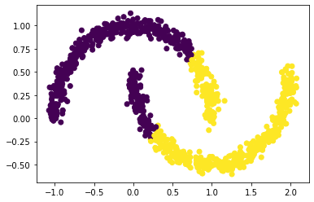

```python
# Write the code for Spectral Clustering with 2 clusters, print the labels and plot the data

clf = SpectralClustering(n_clusters=2, assign_labels='discretize', random_state=0)
clf.fit(X)
plt.scatter(X[:,0],X[:,1],c=clf.labels_)
plt.show()
```

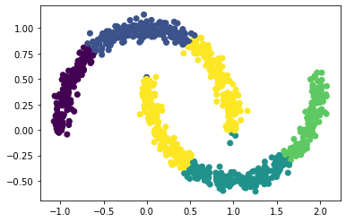

```python
# Write the code for Spectral Clustering with 5 clusters, print the labels and plot the data
clf = SpectralClustering(n_clusters=5, assign_labels='discretize', random_state=0)
clf.fit(X)
plt.scatter(X[:,0],X[:,1],c=clf.labels_)
plt.show()
```

**Write a small summary after observing the 6 figures of the Moons dataset on the top (3 marks)**

# Write the summary here

**This type of clustering is used for unsupervised data. The make_moons is imported from sklearn dataset. With the help of the make_moons a 2D visual view can be classified. Here we imported the clustering algorithms from the sklearn. The algorithms are KMeans,AgglomerativeClustering and SpectralClustering.

**Brief about the above input cell steps.

**In [1]: we import the required functions and algorithms from the dataset and clusters.

In [15]: we have writtern the code for plotting the moon format of the dataset and represented them.

In [16]: we invoke the KMeans by considering the 2 clusters and assign the scattered cordinates to them.With the help of this we represent the moon like visual 2-d view.

In [17]: Similarly,we invoke the KMeans by considering the 5 clusters and assign the scattered cordinates to them.With the help of this we represent the moon like visual 2-d view.

In [18]: Now consider the Agglomerative Clustering, and define the 2 clusters. After that assign to the label variable and then scatter the coordinates and print them in the form of moons with 2-D view.

In [19]: Now consider the Agglomerative Clustering, and define the 5 clusters. After that assign to the label variable and then scatter the coordinates and print them in the form of moons with 2-D view.

In [20]: Now similarly, consider the Spectral Clustering with 2 clusters and define them. Then declare the label and then scatter the coordinates and plot the circle with 2-d view.

In [21]: consider the Spectral Clustering with 5 clusters and define them. Then declare the label and then scatter the coordinates and plot the moon with 2-d view.

**In this way we can visualize the 2-D view for the dataset.**